# Task 3 - Exploratory Data Analysis - IPL Data Set

### Submitted by - Shivank Udayawal

## Problem Statement :

- Exploring Different Datasets about IPL (from 2008 to 2019) & tried to extarct some key insights about this Tournament.
- Using this Data, we will try to understand the insights of Teams, Players & Location which play a key role in increasing the chances of wining.

## Introduction:

- The Indian Premier League (IPL) is a professional Twenty20 cricket league in India.
- Eight Teams representing Eight different cities or states in India.
- The league was founded by the Board of Control for Cricket in India (BCCI) in 2007.

## About Dataset :

### 1. Matches Data :

- Dataset contains information about details of every ipl matches.
- It have Teams, City & Stadium in which match was played, Name of all the Umpires, Winner of toss and toss decision and also the winner.

### 2. Deliveries Data :

- Details of every Deliveries bowled in IPL.

### 3. Runs & Strikerate Data :

- Details about the Runs Scored by every Batter along with their Strike Rate and Average.

### 4. Players Data :

- Details of the Player including their DOB, Batting Hand and the Country they belonged.

### 5. Teams Data :

- Name of all the Teams that have played in the history of IPL.

### 6. Teamwise Home and Away Data :

- How many Matches does a Team Won while playing in Home Stadium and away and their percentage win-loss.

## Importing Libraries

```python
import pandas as pd
import numpy as np
import seaborn as sns
import matplotlib
%matplotlib inline
from matplotlib import pyplot as plt

import warnings
warnings.filterwarnings("ignore")
```

## Reading the Data

```python
sports = pd.read_csv("matches.csv")
deliveries = pd.read_csv("deliveries.csv")
runs = pd.read_csv("most_runs_average_strikerate.csv")
players = pd.read_excel("Players.xlsx")
teams = pd.read_csv("teams.csv")
home_away = pd.read_csv("teamwise_home_and_away.csv")
```

```python
sports.head()
```

|  | id | Season | city | date | team1 | team2 | toss_winner | toss_decision | result | dl_applied | winner | win_by_runs | win_by_wickets | player_of_match | venue | umpire1 | umpire2 | umpire3 |
| --- | --- | --- | --- | --- | --- | --- | --- | --- | --- | --- | --- | --- | --- | --- | --- | --- | --- | --- |
| 0 | 1 | IPL-2017 | Hyderabad | 05-04-2017 | Sunrisers Hyderabad | Royal Challengers Bangalore | Royal Challengers Bangalore | field | normal | 0 | Sunrisers Hyderabad | 35 | 0 | Yuvraj Singh | Rajiv Gandhi International Stadium, Uppal | AY Dandekar | NJ Llong | NaN |
| 1 | 2 | IPL-2017 | Pune | 06-04-2017 | Mumbai Indians | Rising Pune Supergiant | Rising Pune Supergiant | field | normal | 0 | Rising Pune Supergiant | 0 | 7 | SPD Smith | Maharashtra Cricket Association Stadium | A Nand Kishore | S Ravi | NaN |
| 2 | 3 | IPL-2017 | Rajkot | 07-04-2017 | Gujarat Lions | Kolkata Knight Riders | Kolkata Knight Riders | field | normal | 0 | Kolkata Knight Riders | 0 | 10 | CA Lynn | Saurashtra Cricket Association Stadium | Nitin Menon | CK Nandan | NaN |
| 3 | 4 | IPL-2017 | Indore | 08-04-2017 | Rising Pune Supergiant | Kings XI Punjab | Kings XI Punjab | field | normal | 0 | Kings XI Punjab | 0 | 6 | GJ Maxwell | Holkar Cricket Stadium | AK Chaudhary | C Shamshuddin | NaN |
| 4 | 5 | IPL-2017 | Bangalore | 08-04-2017 | Royal Challengers Bangalore | Delhi Daredevils | Royal Challengers Bangalore | bat | normal | 0 | Royal Challengers Bangalore | 15 | 0 | KM Jadhav | M Chinnaswamy Stadium | NaN | NaN | NaN |

```python
deliveries.head()
```

|  | match_id | inning | batting_team | bowling_team | over | ball | batsman | non_striker | bowler | is_super_over | ... | bye_runs | legbye_runs | noball_runs | penalty_runs | batsman_runs | extra_runs | total_runs | player_dismissed | dismissal_kind | fielder |
| --- | --- | --- | --- | --- | --- | --- | --- | --- | --- | --- | --- | --- | --- | --- | --- | --- | --- | --- | --- | --- | --- |
| 0 | 1 | 1 | Sunrisers Hyderabad | Royal Challengers Bangalore | 1 | 1 | DA Warner | S Dhawan | TS Mills | 0 | ... | 0 | 0 | 0 | 0 | 0 | 0 | 0 | NaN | NaN | NaN |
| 1 | 1 | 1 | Sunrisers Hyderabad | Royal Challengers Bangalore | 1 | 2 | DA Warner | S Dhawan | TS Mills | 0 | ... | 0 | 0 | 0 | 0 | 0 | 0 | 0 | NaN | NaN | NaN |
| 2 | 1 | 1 | Sunrisers Hyderabad | Royal Challengers Bangalore | 1 | 3 | DA Warner | S Dhawan | TS Mills | 0 | ... | 0 | 0 | 0 | 0 | 4 | 0 | 4 | NaN | NaN | NaN |
| 3 | 1 | 1 | Sunrisers Hyderabad | Royal Challengers Bangalore | 1 | 4 | DA Warner | S Dhawan | TS Mills | 0 | ... | 0 | 0 | 0 | 0 | 0 | 0 | 0 | NaN | NaN | NaN |
| 4 | 1 | 1 | Sunrisers Hyderabad | Royal Challengers Bangalore | 1 | 5 | DA Warner | S Dhawan | TS Mills | 0 | ... | 0 | 0 | 0 | 0 | 0 | 2 | 2 | NaN | NaN | NaN |

5 rows × 21 columns

```python
runs.head()
```

|  | batsman | total_runs | out | numberofballs | average | strikerate |
| --- | --- | --- | --- | --- | --- | --- |
| 0 | V Kohli | 5426 | 152 | 4111 | 35.697368 | 131.987351 |
| 1 | SK Raina | 5386 | 160 | 3916 | 33.662500 | 137.538304 |
| 2 | RG Sharma | 4902 | 161 | 3742 | 30.447205 | 130.999466 |
| 3 | DA Warner | 4717 | 114 | 3292 | 41.377193 | 143.286756 |
| 4 | S Dhawan | 4601 | 137 | 3665 | 33.583942 | 125.538881 |

```python
players.head()
```

|  | Player_Name | DOB | Batting_Hand | Bowling_Skill | Country |
| --- | --- | --- | --- | --- | --- |
| 0 | A Ashish Reddy | 1991-02-24 | Right_Hand | Right-arm medium | India |
| 1 | A Chandila | 1983-12-05 | Right_Hand | Right-arm offbreak | India |
| 2 | A Chopra | 1977-09-19 | Right_Hand | Right-arm offbreak | India |
| 3 | A Choudhary | NaT | Right_hand | Left-arm fast-medium | NaN |
| 4 | A Dananjaya | NaT | Right_Hand | Right-arm offbreak | NaN |

```python
teams.head()
```

|  | team1 |
| --- | --- |
| 0 | Pune Warriors |
| 1 | Kolkata Knight Riders |
| 2 | Rajasthan Royals |
| 3 | Kochi Tuskers Kerala |
| 4 | Gujarat Lions |

```python
home_away.head()
```

|  | team | home_wins | away_wins | home_matches | away_matches | home_win_percentage | away_win_percentage |
| --- | --- | --- | --- | --- | --- | --- | --- |
| 0 | Rising Pune Supergiant | 5 | 5 | 8 | 8 | 62.500000 | 62.500000 |
| 1 | Mumbai Indians | 58 | 51 | 101 | 86 | 57.425743 | 59.302326 |
| 2 | Chennai Super Kings | 51 | 49 | 89 | 75 | 57.303371 | 65.333333 |
| 3 | Delhi Capitals | 3 | 7 | 6 | 10 | 50.000000 | 70.000000 |
| 4 | Sunrisers Hyderabad | 30 | 28 | 63 | 45 | 47.619048 | 62.222222 |

```python
print("sports Data shape     :" , sports.shape)
print("deliveries Data shape :" , deliveries.shape)
print("runs Data shape       :" , runs.shape)
print("players Data shape    :" , players.shape)
print("teams Data shape      :" , teams.shape)
print("home_away Data shape  :" , home_away.shape)
```

```
sports Data shape     : (756, 18)
deliveries Data shape : (179078, 21)
runs Data shape       : (516, 6)
players Data shape    : (566, 5)
teams Data shape      : (15, 1)
home_away Data shape  : (14, 7)
```

## Exploratory Data Analysis

```python
merge = pd.merge(deliveries, sports, left_on = 'match_id', right_on ='id')
merge.head(2)
```

|  | match_id | inning | batting_team | bowling_team | over | ball | batsman | non_striker | bowler | is_super_over | ... | result | dl_applied | winner | win_by_runs | win_by_wickets | player_of_match | venue | umpire1 | umpire2 | umpire3 |
| --- | --- | --- | --- | --- | --- | --- | --- | --- | --- | --- | --- | --- | --- | --- | --- | --- | --- | --- | --- | --- | --- |
| 0 | 1 | 1 | Sunrisers Hyderabad | Royal Challengers Bangalore | 1 | 1 | DA Warner | S Dhawan | TS Mills | 0 | ... | normal | 0 | Sunrisers Hyderabad | 35 | 0 | Yuvraj Singh | Rajiv Gandhi International Stadium, Uppal | AY Dandekar | NJ Llong | NaN |
| 1 | 1 | 1 | Sunrisers Hyderabad | Royal Challengers Bangalore | 1 | 2 | DA Warner | S Dhawan | TS Mills | 0 | ... | normal | 0 | Sunrisers Hyderabad | 35 | 0 | Yuvraj Singh | Rajiv Gandhi International Stadium, Uppal | AY Dandekar | NJ Llong | NaN |

2 rows × 39 columns

```python
sports.isnull().sum()
```

```
id                   0
Season               0
city                 7
date                 0
team1                0
team2                0
toss_winner          0
toss_decision        0
result               0
dl_applied           0
winner               4
win_by_runs          0
win_by_wickets       0
player_of_match      4
venue                0
umpire1              2
umpire2              2
umpire3            637
dtype: int64
```

```python
sports.head()
```

|  | id | Season | city | date | team1 | team2 | toss_winner | toss_decision | result | dl_applied | winner | win_by_runs | win_by_wickets | player_of_match | venue | umpire1 | umpire2 | umpire3 |
| --- | --- | --- | --- | --- | --- | --- | --- | --- | --- | --- | --- | --- | --- | --- | --- | --- | --- | --- |
| 0 | 1 | IPL-2017 | Hyderabad | 05-04-2017 | Sunrisers Hyderabad | Royal Challengers Bangalore | Royal Challengers Bangalore | field | normal | 0 | Sunrisers Hyderabad | 35 | 0 | Yuvraj Singh | Rajiv Gandhi International Stadium, Uppal | AY Dandekar | NJ Llong | NaN |
| 1 | 2 | IPL-2017 | Pune | 06-04-2017 | Mumbai Indians | Rising Pune Supergiant | Rising Pune Supergiant | field | normal | 0 | Rising Pune Supergiant | 0 | 7 | SPD Smith | Maharashtra Cricket Association Stadium | A Nand Kishore | S Ravi | NaN |
| 2 | 3 | IPL-2017 | Rajkot | 07-04-2017 | Gujarat Lions | Kolkata Knight Riders | Kolkata Knight Riders | field | normal | 0 | Kolkata Knight Riders | 0 | 10 | CA Lynn | Saurashtra Cricket Association Stadium | Nitin Menon | CK Nandan | NaN |
| 3 | 4 | IPL-2017 | Indore | 08-04-2017 | Rising Pune Supergiant | Kings XI Punjab | Kings XI Punjab | field | normal | 0 | Kings XI Punjab | 0 | 6 | GJ Maxwell | Holkar Cricket Stadium | AK Chaudhary | C Shamshuddin | NaN |
| 4 | 5 | IPL-2017 | Bangalore | 08-04-2017 | Royal Challengers Bangalore | Delhi Daredevils | Royal Challengers Bangalore | bat | normal | 0 | Royal Challengers Bangalore | 15 | 0 | KM Jadhav | M Chinnaswamy Stadium | NaN | NaN | NaN |

```python
sports[sports.city.isnull()][['city','venue']]
```

|  | city | venue |
| --- | --- | --- |
| 461 | NaN | Dubai International Cricket Stadium |
| 462 | NaN | Dubai International Cricket Stadium |
| 466 | NaN | Dubai International Cricket Stadium |
| 468 | NaN | Dubai International Cricket Stadium |
| 469 | NaN | Dubai International Cricket Stadium |
| 474 | NaN | Dubai International Cricket Stadium |
| 476 | NaN | Dubai International Cricket Stadium |

```python
sports['city'].fillna('Dubai', inplace = True)
```

```python
sports[sports.winner.isnull()][['winner','result','win_by_wickets','team1','team2']]
```

|  | winner | result | win_by_wickets | team1 | team2 |
| --- | --- | --- | --- | --- | --- |
| 300 | NaN | no result | 0 | Delhi Daredevils | Pune Warriors |
| 545 | NaN | no result | 0 | Royal Challengers Bangalore | Rajasthan Royals |
| 570 | NaN | no result | 0 | Delhi Daredevils | Royal Challengers Bangalore |
| 744 | NaN | no result | 0 | Royal Challengers Bangalore | Rajasthan Royals |

```python
sports[sports.player_of_match.isnull()][['winner','player_of_match','result','team1','team2']]
```

|  | winner | player_of_match | result | team1 | team2 |
| --- | --- | --- | --- | --- | --- |
| 300 | NaN | NaN | no result | Delhi Daredevils | Pune Warriors |
| 545 | NaN | NaN | no result | Royal Challengers Bangalore | Rajasthan Royals |
| 570 | NaN | NaN | no result | Delhi Daredevils | Royal Challengers Bangalore |
| 744 | NaN | NaN | no result | Royal Challengers Bangalore | Rajasthan Royals |

```python
sports['winner'].fillna('Draw', inplace = True)
sports['player_of_match'].fillna('Draw', inplace = True)
```

```python
sports[(sports.umpire1.isnull()) | (sports.umpire2.isnull())]
```

|  | id | Season | city | date | team1 | team2 | toss_winner | toss_decision | result | dl_applied | winner | win_by_runs | win_by_wickets | player_of_match | venue | umpire1 | umpire2 | umpire3 |
| --- | --- | --- | --- | --- | --- | --- | --- | --- | --- | --- | --- | --- | --- | --- | --- | --- | --- | --- |
| 4 | 5 | IPL-2017 | Bangalore | 08-04-2017 | Royal Challengers Bangalore | Delhi Daredevils | Royal Challengers Bangalore | bat | normal | 0 | Royal Challengers Bangalore | 15 | 0 | KM Jadhav | M Chinnaswamy Stadium | NaN | NaN | NaN |
| 753 | 11413 | IPL-2019 | Visakhapatnam | 08-05-2019 | Sunrisers Hyderabad | Delhi Capitals | Delhi Capitals | field | normal | 0 | Delhi Capitals | 0 | 2 | RR Pant | ACA-VDCA Stadium | NaN | NaN | NaN |

```python
sports = sports.drop('umpire3', axis = 1)
```

```python
def name_changer(data):
    if data == 'Delhi Daredevils':
        data = 'Delhi Capitals'
    elif data == 'Deccan Chargers':
        data = 'Sunrisers Hyderabad'
    elif data == 'Pune Warriors' or data == 'Rising Pune Supergiant':
        data = 'Rising Pune Supergiants'
    return data
```

```python
sports['team1'] = sports['team1'].apply(lambda x:name_changer(x))
sports['team2'] = sports['team2'].apply(lambda x:name_changer(x))
sports['toss_winner'] = sports['toss_winner'].apply(lambda x:name_changer(x))
sports['winner'] = sports['winner'].apply(lambda x:name_changer(x))
```

```python
city_venue = sports.groupby(['city','venue']).count()['Season']
city_venue_df = pd.DataFrame(city_venue)
city_venue_df
```

| city | venue | Season |
| --- | --- | --- |
| Abu Dhabi | Sheikh Zayed Stadium | 7 |
| Ahmedabad | Sardar Patel Stadium, Motera | 12 |
| Bangalore | M Chinnaswamy Stadium | 66 |
| Bengaluru | M Chinnaswamy Stadium | 7 |
|  | M. Chinnaswamy Stadium | 7 |
| Bloemfontein | OUTsurance Oval | 2 |
| Cape Town | Newlands | 7 |
| Centurion | SuperSport Park | 12 |
| Chandigarh | Punjab Cricket Association IS Bindra Stadium, Mohali | 11 |
|  | Punjab Cricket Association Stadium, Mohali | 35 |
| Chennai | M. A. Chidambaram Stadium | 8 |
|  | MA Chidambaram Stadium, Chepauk | 49 |
| Cuttack | Barabati Stadium | 7 |
| Delhi | Feroz Shah Kotla | 67 |
|  | Feroz Shah Kotla Ground | 7 |
| Dharamsala | Himachal Pradesh Cricket Association Stadium | 9 |
| Dubai | Dubai International Cricket Stadium | 7 |
| Durban | Kingsmead | 15 |
| East London | Buffalo Park | 3 |
| Hyderabad | Rajiv Gandhi International Stadium, Uppal | 56 |
|  | Rajiv Gandhi Intl. Cricket Stadium | 8 |
| Indore | Holkar Cricket Stadium | 9 |
| Jaipur | Sawai Mansingh Stadium | 47 |
| Johannesburg | New Wanderers Stadium | 8 |
| Kanpur | Green Park | 4 |
| Kimberley | De Beers Diamond Oval | 3 |
| Kochi | Nehru Stadium | 5 |
| Kolkata | Eden Gardens | 77 |
| Mohali | IS Bindra Stadium | 7 |
|  | Punjab Cricket Association IS Bindra Stadium, Mohali | 3 |
| Mumbai | Brabourne Stadium | 11 |
|  | Dr DY Patil Sports Academy | 17 |
|  | Wankhede Stadium | 73 |
| Nagpur | Vidarbha Cricket Association Stadium, Jamtha | 3 |
| Port Elizabeth | St George's Park | 7 |
| Pune | Maharashtra Cricket Association Stadium | 21 |
|  | Subrata Roy Sahara Stadium | 17 |
| Raipur | Shaheed Veer Narayan Singh International Stadium | 6 |
| Rajkot | Saurashtra Cricket Association Stadium | 10 |
| Ranchi | JSCA International Stadium Complex | 7 |
| Sharjah | Sharjah Cricket Stadium | 6 |
| Visakhapatnam | ACA-VDCA Stadium | 2 |
|  | Dr. Y.S. Rajasekhara Reddy ACA-VDCA Cricket Stadium | 11 |

- Bengaluru and Bangalore both are in the data when they are same. So we need to keep one of them.
- Chandigarh and Mohali are same and there is just one stadium Punjab Cricket Association IS Bindra Stadium, Mohali whose value has not been entered correctly. We need to have either Chandigarh or Mohali as well as correct name of the stadium there.
- Mumbai has 3 stadiums/venues used for IPL.
- Pune has 2 venues for IPL.

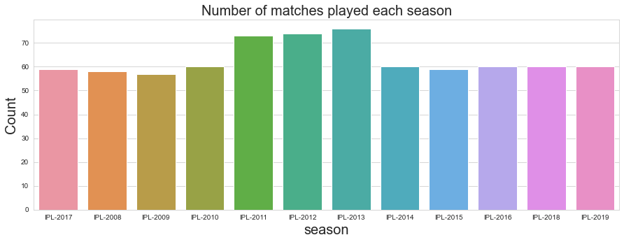

```python
sns.set_style('whitegrid')
plt.figure(figsize=(15,5))
sns.countplot(x = 'Season', data = sports)
plt.title("Number of matches played each season", size = 20)
plt.xlabel("season", size = 20)
plt.ylabel("Count", size = 20)
```

- As seen clearly Season held in 2011,2012,2013 have more matches than other seasons.
- Season held in 2011,2012,2013 have more than 70 matches.
- All other Seasons have approximately 58-60 matches

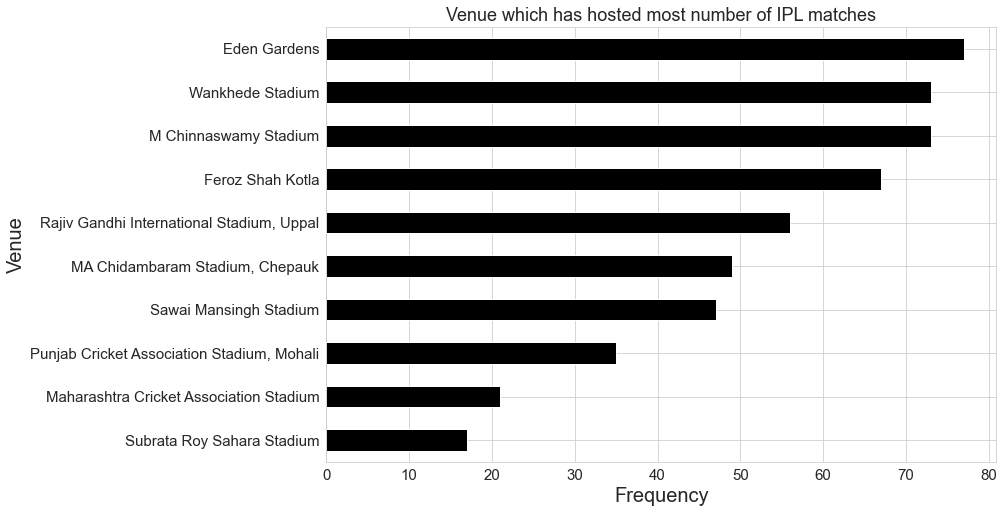

```python
host = sports['venue'].value_counts().sort_values(ascending = True).tail(10)

host.plot(kind = 'barh',figsize = (12,8), fontsize = 15, color = 'black')
plt.title("Venue which has hosted most number of IPL matches", fontsize = 18)
plt.ylabel("Venue", size = 20)
plt.xlabel("Frequency", size = 20)
```

- Eden gardens of Kolkata has hosted maximum number of matches.

```python
sports['winner'].value_counts()
```

```
Mumbai Indians                 109
Chennai Super Kings            100
Kolkata Knight Riders           92
Sunrisers Hyderabad             87
Royal Challengers Bangalore     84
Kings XI Punjab                 82
Delhi Capitals                  77
Rajasthan Royals                75
Rising Pune Supergiants         27
Gujarat Lions                   13
Kochi Tuskers Kerala             6
Draw                             4
Name: winner, dtype: int64
```

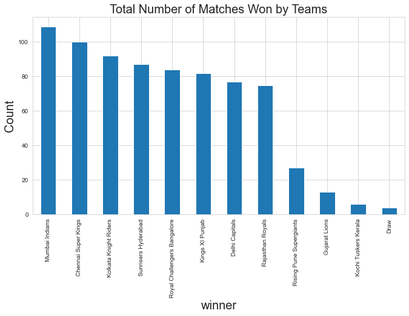

```python
extra = sports['winner'].value_counts().sort_values(axis = 0, ascending = False)
extra.plot(kind = 'bar', figsize = (11,6))
plt.title("Total Number of Matches Won by Teams", size=20)
plt.xlabel('winner',size = 20)
plt.ylabel('Count',size = 20)
plt.show()
```

- Most successful team in IPL history is Mumbai Indians with 109 wins.
- Chennai Super Kings is in Second position with 100 wins.
- Kochi Tuskers Kerala on the last spot with just 6 wins.

```python
total_match = sports.team1.value_counts()+sports.team2.value_counts()
total_match.sort_values(ascending = False)
```

```
Mumbai Indians                 187
Sunrisers Hyderabad            183
Royal Challengers Bangalore    180
Kolkata Knight Riders          178
Delhi Capitals                 177
Kings XI Punjab                176
Chennai Super Kings            164
Rajasthan Royals               147
Rising Pune Supergiants         76
Gujarat Lions                   30
Kochi Tuskers Kerala            14
dtype: int64
```

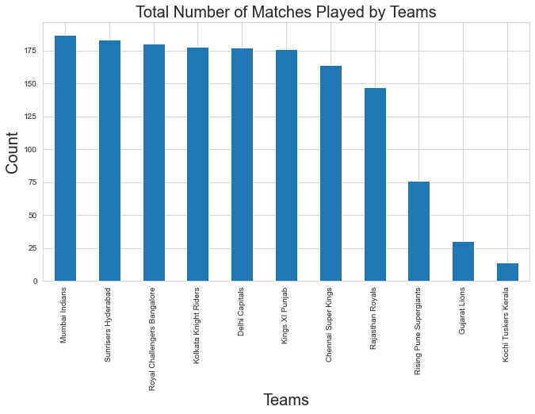

```python
extra = total_match.sort_values(ascending = False)
extra.plot(kind = 'bar', figsize = (11,6))
plt.title("Total Number of Matches Played by Teams", size=20)
plt.xlabel('Teams',size = 20)
plt.ylabel('Count',size = 20)
plt.show()
```

- Mumbai Indians has played the most matches of 187. since Mumbai Indians(MI) has won most matches so they surely survived enough to play more knockout matches which adds up to this.

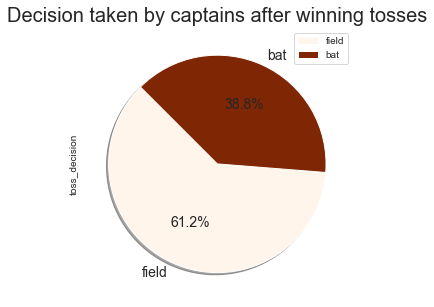

```python
toss = sports['toss_decision'].value_counts()

toss.plot(kind = 'pie', fontsize = 14, autopct = '%3.1f%%', figsize = (8,5), shadow = True, startangle = 135, legend = True,
          cmap = 'Oranges')
plt.title('Decision taken by captains after winning tosses', size = 20)
```

- 61% times teams choose to field first after winning the toss.

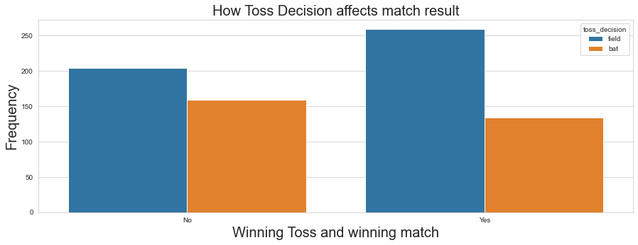

```python
sports['toss_win_game_win'] = np.where((sports.toss_winner == sports.winner),'Yes','No')

plt.figure(figsize = (15,5))
sns.countplot('toss_win_game_win', data=sports, hue = 'toss_decision')
plt.title("How Toss Decision affects match result", fontsize = 20)
plt.xlabel("Winning Toss and winning match", fontsize = 20)
plt.ylabel("Frequency", fontsize = 20)
```

- Teams winning tosses and electng to field first have won most number of times.

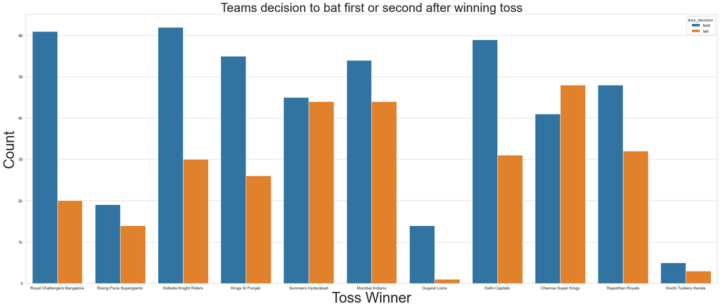

```python
plt.figure(figsize = (30,12))
sns.countplot('toss_winner', data = sports, hue = 'toss_decision')
plt.title("Teams decision to bat first or second after winning toss", size = 30)
plt.xlabel("Toss Winner", size = 35)
plt.ylabel("Count", size = 35)
```

- Most teams field first after winning toss except for Chennai Super Kings who has mostly opted to bat first.

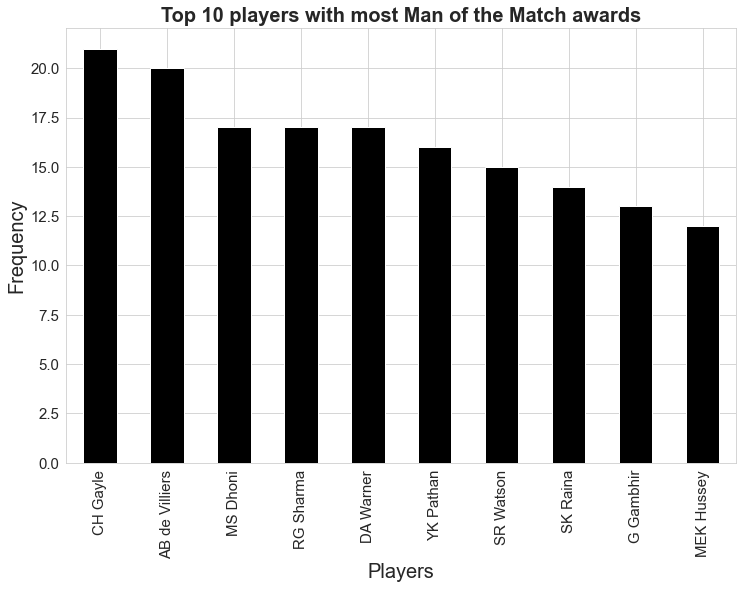

```python
MoM = sports['player_of_match'].value_counts()
MoM.head(10).plot(kind = 'bar',figsize = (12,8), fontsize = 15, color = 'black')
plt.title("Top 10 players with most Man of the Match awards",fontsize = 20, fontweight ="bold")
plt.ylabel("Frequency", size = 20)
plt.xlabel("Players", size = 20)
```

- Chris Gayle has so far won the most number of MoM(Man of the Match) awards followed by AB de Villiers.
- Also, all top 10 are batsmen which kind of hints that in IPL batsmen have mostly dictated the matches

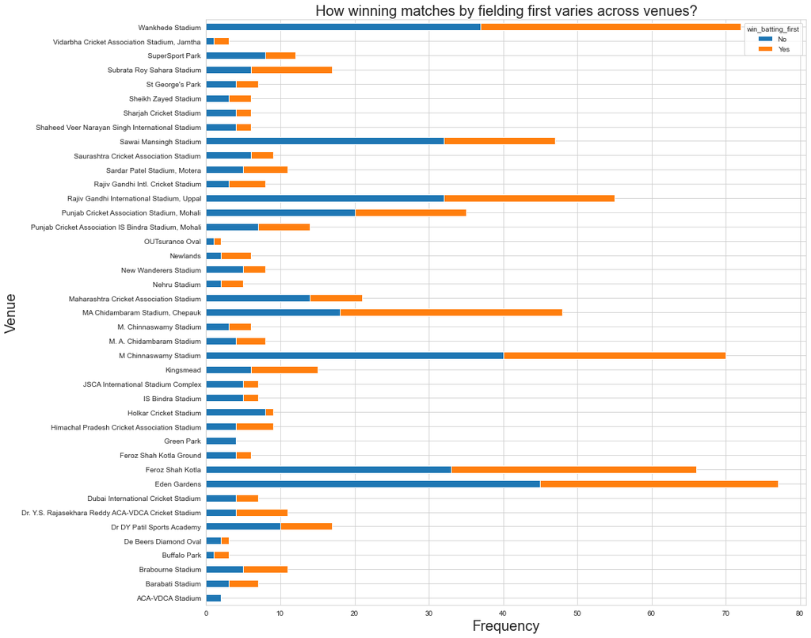

```python
new_matches = sports[sports['result'] == 'normal']
new_matches['win_batting_first'] = np.where((new_matches.win_by_runs > 0), 'Yes', 'No')
new_matches.groupby('venue')['win_batting_first'].value_counts().unstack().plot(kind = 'barh', stacked = True, figsize =(15,15))


plt.title("How winning matches by fielding first varies across venues?", fontsize = 20)
plt.xlabel("Frequency", fontsize = 20)
plt.ylabel("Venue", fontsize = 20)
```

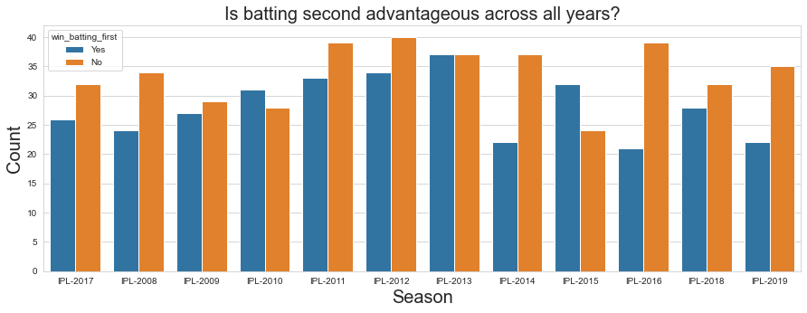

```python
plt.figure(figsize = (15,5))
sns.countplot('Season', data = new_matches, hue = 'win_batting_first')
plt.title("Is batting second advantageous across all years?", fontsize = 20)
plt.xlabel("Season", fontsize = 20)
plt.ylabel("Count", fontsize = 20)
```

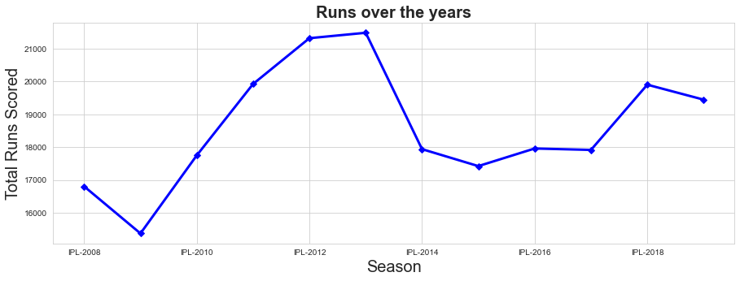

```python
merge.groupby('Season')['batsman_runs'].sum().plot(kind = 'line', linewidth = 3, figsize = (15,5), color = 'blue', marker = 'D')
plt.title("Runs over the years", fontsize = 20, fontweight = 'bold')
plt.xlabel("Season", size = 20)
plt.ylabel("Total Runs Scored", size = 20)
```

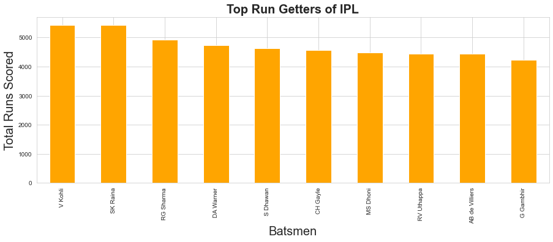

```python
merge.groupby('batsman')['batsman_runs'].sum().sort_values(ascending = False).head(10).plot(kind = 'bar',
                                                                                            color = 'orange', figsize = (15,5))

plt.title("Top Run Getters of IPL", fontsize = 20, fontweight = 'bold')
plt.xlabel("Batsmen", size = 20)
plt.ylabel("Total Runs Scored", size = 20)
```

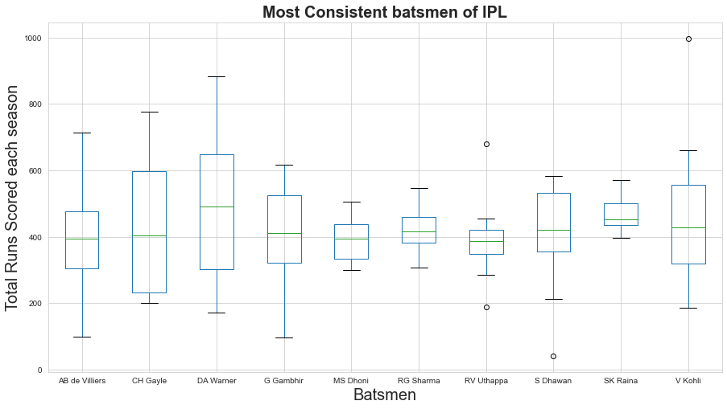

```python
consistent_batsman = merge[merge.batsman.isin(['SK Raina', 'V Kohli','RG Sharma','G Gambhir','RV Uthappa', 'S Dhawan',
                                               'CH Gayle', 'MS Dhoni', 'DA Warner', 'AB de Villiers'])]
[['batsman','season','total_runs']]

consistent_batsman.groupby(['Season','batsman'])['total_runs'].sum().unstack().plot(kind = 'box', figsize = (15,8))
plt.title("Most Consistent batsmen of IPL", fontsize = 20, fontweight = 'bold')
plt.xlabel("Batsmen", size = 20)
plt.ylabel("Total Runs Scored each season", size = 20)
```

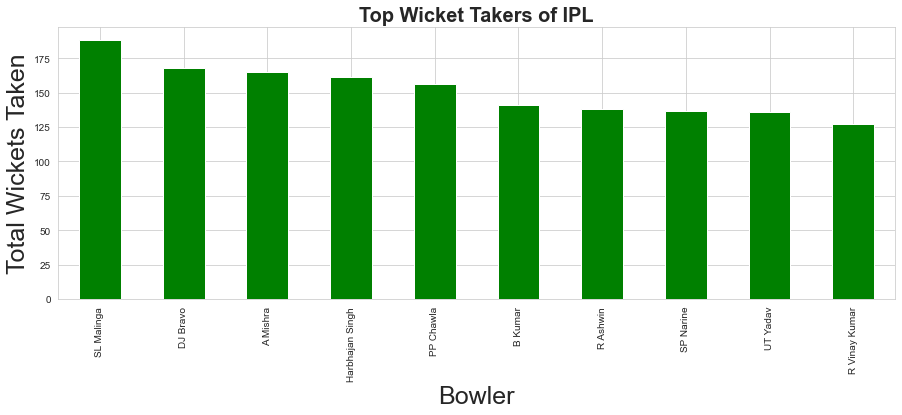

```python
merge.groupby('bowler')['player_dismissed'].count().sort_values(ascending = False).head(10).plot(kind = 'bar',
                                                color = 'Green', figsize = (15,5))
plt.title("Top Wicket Takers of IPL", fontsize = 20, fontweight = 'bold')
plt.xlabel("Bowler", size = 25)
plt.ylabel("Total Wickets Taken", size = 25)
```

- Malinga has taken the most number of wickets in IPL followed by Bravo and Amit Mishra.
- In top 10 bowlers, 5 are fast and medium pacers while the other 5 are spinners.
- All 5 spinners are right arm spinners and 2 are leg spinners while 3 are off spinners.
- All 5 pacers are right arm pacer.

```python
max_avg = runs.sort_values('average',ascending = False)
max_strikerate = runs.sort_values('strikerate',ascending = False)
max_total_runs = runs.sort_values('total_runs',ascending = False)
max_out = runs.sort_values('out',ascending = False)
max_strikerate = runs[runs['total_runs']>3000].sort_values('strikerate',ascending = False)
```

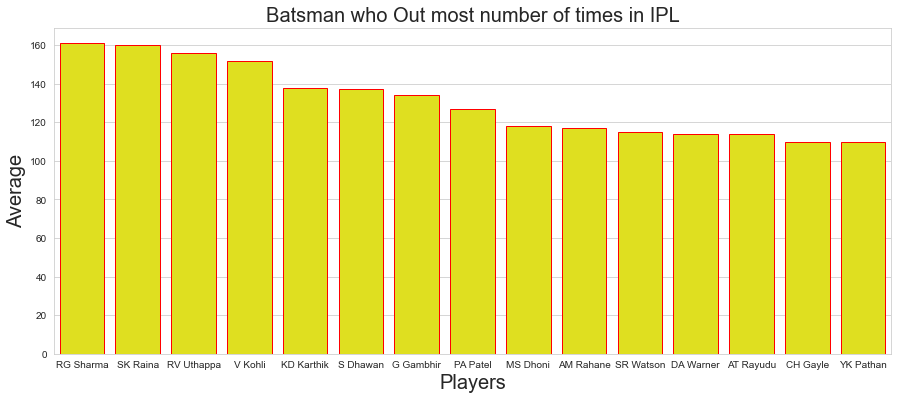

```python
plt.figure(figsize = (15,6))
sns.barplot(x = 'batsman', y = 'out', data = max_out.head(15), color = 'yellow', edgecolor = 'red')
plt.title("Batsman who Out most number of times in IPL",fontsize= 20)
plt.xlabel("Players", size = 20)
plt.ylabel("Average", size = 20)
```

- RG Sharma Out most of the time in IPL history.
- SK Raina is on second position.
- All the Batsman are of top orders i.e Opening Batsman.

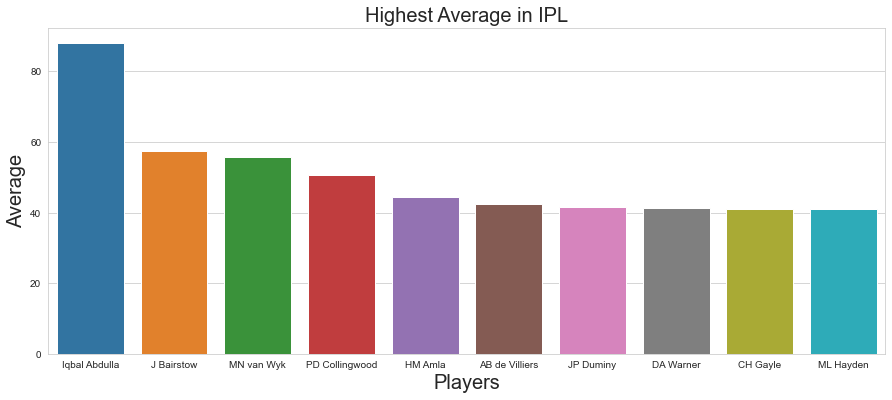

```python
plt.figure(figsize = (15,6))
sns.barplot(x = 'batsman', y = 'average', data = max_avg.head(10))
plt.title("Highest Average in IPL",fontsize= 20)
plt.xlabel("Players", size = 20)
plt.ylabel("Average", size = 20)
```

- Iqbal Abdulla has the highest Average in IPL.
- J Bairstow is in second spot.

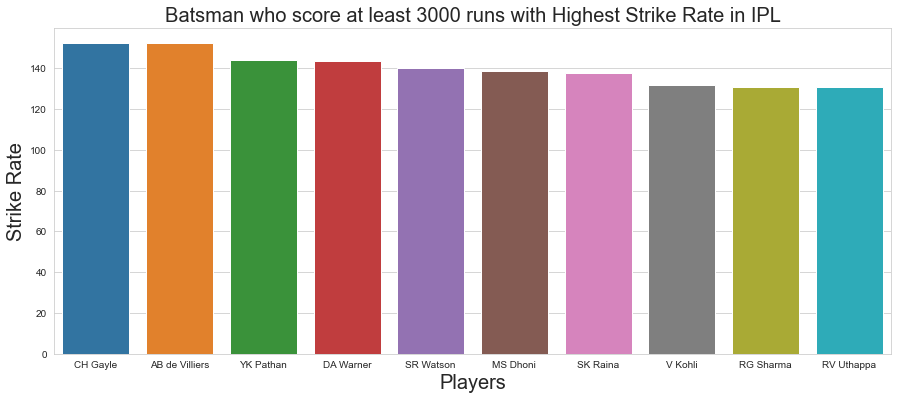

```python
plt.figure(figsize = (15,6))
sns.barplot(x = 'batsman', y = 'strikerate', data = max_strikerate.head(10))
plt.title("Batsman who score at least 3000 runs with Highest Strike Rate in IPL", fontsize = 20)
plt.xlabel("Players", size = 20)
plt.ylabel("Strike Rate", size = 20)
```

- CH Gayle & AB de Villiers are the most strike rate Batsman in IPL.

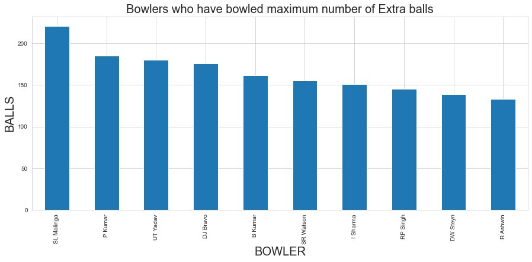

|  | SL Malinga | P Kumar | UT Yadav | DJ Bravo | B Kumar | SR Watson | I Sharma | RP Singh | DW Steyn | R Ashwin |
| --- | --- | --- | --- | --- | --- | --- | --- | --- | --- | --- |
| bowler | 221 | 185 | 180 | 176 | 162 | 155 | 151 | 145 | 139 | 133 |

```python
extra = deliveries[deliveries['extra_runs']!= 0]['bowler'].value_counts()[:10]
extra.plot(kind = 'bar', figsize = (15,6))
plt.title('Bowlers who have bowled maximum number of Extra balls', size = 20)
plt.xlabel('BOWLER', size = 20)
plt.ylabel('BALLS',size = 20)
plt.show()

extra = pd.DataFrame(extra)
extra.T
```

- SL Malinga is the highest wicket taking bolwer but he is also most giving extras.

```python
balls_bowled = pd.DataFrame(merge.groupby('bowler')['ball'].count())
wickets_taken = pd.DataFrame(merge[merge['dismissal_kind'] != 'no dismissal'].groupby('bowler')['dismissal_kind'].count())
seasons_played = pd.DataFrame(merge.groupby('bowler')['Season'].nunique())
bowler_strike_rate = pd.DataFrame({'balls':balls_bowled['ball'],'wickets':wickets_taken['dismissal_kind'],
                          'Season':seasons_played['Season']})
bowler_strike_rate.reset_index(inplace = True)

bowler_strike_rate['strike_rate'] = bowler_strike_rate['balls']/bowler_strike_rate['wickets']
def highlight_cols(s):
    color = 'skyblue'
    return 'background-color: %s' % color


best_bowling_strike_rate = bowler_strike_rate[bowler_strike_rate['wickets'] > 50].sort_values(by = 'strike_rate', ascending = True)
best_bowling_strike_rate.head(10).style.applymap(highlight_cols, subset = pd.IndexSlice[:, ['bowler', 'wickets','strike_rate']])
```

|  | bowler | balls | wickets | Season | strike_rate |
| --- | --- | --- | --- | --- | --- |
| 134 | Imran Tahir | 1249 | 82 | 6 | 15.231707 |
| 340 | SL Malinga | 2974 | 188 | 9 | 15.819149 |
| 93 | DJ Bravo | 2711 | 168 | 10 | 16.136905 |
| 9 | A Nehra | 1974 | 121 | 9 | 16.314050 |
| 225 | MM Patel | 1382 | 82 | 7 | 16.853659 |
| 158 | JP Faulkner | 1287 | 76 | 7 | 16.934211 |
| 74 | CH Morris | 1335 | 78 | 6 | 17.115385 |
| 358 | Sandeep Sharma | 1546 | 90 | 6 | 17.177778 |
| 281 | R Vinay Kumar | 2186 | 127 | 11 | 17.212598 |
| 28 | AD Russell | 1072 | 60 | 7 | 17.866667 |

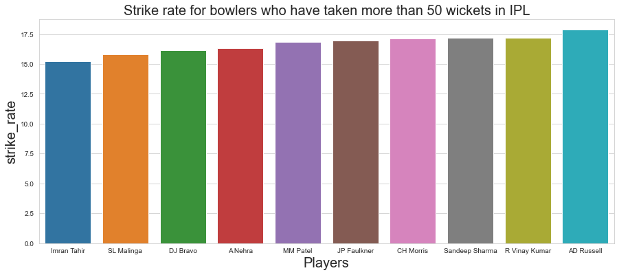

```python
plt.figure(figsize = (15,6))
sns.barplot(x = 'bowler', y = 'strike_rate', data = best_bowling_strike_rate.head(10))
plt.title("Strike rate for bowlers who have taken more than 50 wickets in IPL", fontsize = 20)
plt.xlabel("Players", size = 20)
plt.ylabel("strike_rate", size = 20)
```

- SL Malinga, DJ Bravo, A Nehra are the bowlers who took most wickets with best bowling strikerate.

```python
def name_changer(data):
    if data == 'Delhi Daredevils':
        data = 'Delhi Capitals'
    elif data == 'Deccan Chargers':
        data = 'Sunrisers Hyderabad'
    elif data == 'Pune Warriors' or data == 'Rising Pune Supergiant':
        data = 'Rising Pune Supergiants'
    return data

home_away['team'] = home_away['team'].apply(lambda x:name_changer(x))
```

```python
home_away = home_away.append({"team":"Delhi_Capitals","home_wins":"28","away_wins":"49","home_matches":"78",
                                      "away_matches":"99","home_win_percentage":"42.36111","away_win_percentage":"58.50000"},
                                     ignore_index = True)

home_away = home_away.append({"team":"Sunrisers Hyderabad","home_wins":"48","away_wins":"39","home_matches":"106",
                                        "away_matches":"77","home_win_percentage":"44.73","away_win_percentage":"48.29"},
                                       ignore_index = True)

home_away = home_away.append({"team":"Rising Pune Supergiants","home_wins":"11","away_wins":"11","home_matches":"28",
                                        "away_matches":"34","home_win_percentage":"39.28","away_win_percentage":"32.35"},
                                       ignore_index = True)

home_away.drop([0,3,4,6,10,11], axis = 0, inplace = True)
```

```python
home_away['home_win_percentage'] = home_away['home_win_percentage'].astype('float')
home_away['away_win_percentage'] = home_away['away_win_percentage'].astype('float')
home_away
```

|  | team | home_wins | away_wins | home_matches | away_matches | home_win_percentage | away_win_percentage |
| --- | --- | --- | --- | --- | --- | --- | --- |
| 1 | Mumbai Indians | 58 | 51 | 101 | 86 | 57.425743 | 59.302326 |
| 2 | Chennai Super Kings | 51 | 49 | 89 | 75 | 57.303371 | 65.333333 |
| 5 | Rajasthan Royals | 29 | 46 | 67 | 80 | 43.283582 | 57.500000 |
| 7 | Kings XI Punjab | 38 | 44 | 91 | 85 | 41.758242 | 51.764706 |
| 8 | Royal Challengers Bangalore | 35 | 49 | 85 | 95 | 41.176471 | 51.578947 |
| 9 | Kolkata Knight Riders | 34 | 58 | 83 | 95 | 40.963855 | 61.052632 |
| 12 | Kochi Tuskers Kerala | 2 | 4 | 7 | 7 | 28.571429 | 57.142857 |
| 13 | Gujarat Lions | 1 | 12 | 14 | 16 | 7.142857 | 75.000000 |
| 14 | Delhi_Capitals | 28 | 49 | 78 | 99 | 42.361110 | 58.500000 |
| 15 | Sunrisers Hyderabad | 48 | 39 | 106 | 77 | 44.730000 | 48.290000 |
| 16 | Rising Pune Supergiants | 11 | 11 | 28 | 34 | 39.280000 | 32.350000 |

```python
home_wins = home_away[['team','home_win_percentage']]
home_wins.sort_values('home_win_percentage', ascending = False)
```

|  | team | home_win_percentage |
| --- | --- | --- |
| 1 | Mumbai Indians | 57.425743 |
| 2 | Chennai Super Kings | 57.303371 |
| 15 | Sunrisers Hyderabad | 44.730000 |
| 5 | Rajasthan Royals | 43.283582 |
| 14 | Delhi_Capitals | 42.361110 |
| 7 | Kings XI Punjab | 41.758242 |
| 8 | Royal Challengers Bangalore | 41.176471 |
| 9 | Kolkata Knight Riders | 40.963855 |
| 16 | Rising Pune Supergiants | 39.280000 |
| 12 | Kochi Tuskers Kerala | 28.571429 |
| 13 | Gujarat Lions | 7.142857 |

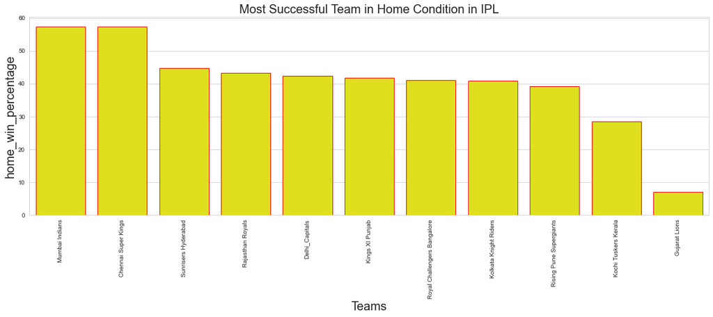

```python
plt.figure(figsize = (20,6))
sns.barplot(x = 'team', y = 'home_win_percentage', data = home_wins.sort_values('home_win_percentage', ascending = False),
           color = 'yellow', edgecolor = 'red')
plt.title("Most Successful Team in Home Condition in IPL", fontsize = 20)
plt.xticks(rotation = 90, horizontalalignment = "center")
plt.xlabel("Teams", size = 20)
plt.ylabel("home_win_percentage", size = 20)
```

- Most successful team in home condution is Mumbai Indians with Win % of 57.42.
- Chennai Super Kings is also have Win % of 57.30.

```python
away_wins = home_away[['team','away_win_percentage']]
away_wins.sort_values('away_win_percentage', ascending = False)
```

|  | team | away_win_percentage |
| --- | --- | --- |
| 13 | Gujarat Lions | 75.000000 |
| 2 | Chennai Super Kings | 65.333333 |
| 9 | Kolkata Knight Riders | 61.052632 |
| 1 | Mumbai Indians | 59.302326 |
| 14 | Delhi_Capitals | 58.500000 |
| 5 | Rajasthan Royals | 57.500000 |
| 12 | Kochi Tuskers Kerala | 57.142857 |
| 7 | Kings XI Punjab | 51.764706 |
| 8 | Royal Challengers Bangalore | 51.578947 |
| 15 | Sunrisers Hyderabad | 48.290000 |
| 16 | Rising Pune Supergiants | 32.350000 |

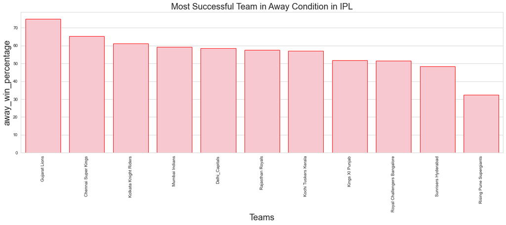

```python
plt.figure(figsize = (20,6))
sns.barplot(x = 'team', y = 'away_win_percentage', data = away_wins.sort_values('away_win_percentage', ascending = False),
           color = 'pink', edgecolor = 'red')
plt.title("Most Successful Team in Away Condition in IPL", fontsize = 20)
plt.xticks(rotation = 90, horizontalalignment = "center")
plt.xlabel("Teams", size = 20)
plt.ylabel("away_win_percentage", size = 20)
```

- Gujrat lion has the highest away win % but it has played very less matches.
- Chennai Super Kings have most away wins % of 65.33% .
- Kolkata Knight Riders also have same tred away wins % of 61% .